# Predict survival on the Titanic

Machine Learning from Disaster

Jiwon

2019. 9. 28

# 1. 주제 및 데이터 선정

Kaggle competition 중 하나로 머신러닝으로 유명한 타이타닉 생존자 예측데이터입니다.

```r
train<-read.csv("D:\\data\\titanic\\train.csv", header=T, stringsAsFactors = F)
test<-read.csv("D:\\data\\titanic\\test.csv", header=T, stringsAsFactors = F)
#str(train)
#str(test)

tdata<- dplyr::bind_rows(train, test)
#str(tdata)
#head(tdata)
```

# 2. 데이터 탐색

## 2-1. 컬럼 소개

```r
str(tdata)
```

```
'data.frame':   1309 obs. of  12 variables:
 $ PassengerId: int  1 2 3 4 5 6 7 8 9 10 ...
 $ Survived   : int  0 1 1 1 0 0 0 0 1 1 ...
 $ Pclass     : int  3 1 3 1 3 3 1 3 3 2 ...
 $ Name       : chr  "Braund, Mr. Owen Harris" "Cumings, Mrs. John Bradley (Florence Briggs Thayer)" "Heikkinen, Miss. Laina" "Futrelle, Mrs. Jacques Heath (Lily May Peel)" ...
 $ Sex        : chr  "male" "female" "female" "female" ...
 $ Age        : num  22 38 26 35 35 NA 54 2 27 14 ...
 $ SibSp      : int  1 1 0 1 0 0 0 3 0 1 ...
 $ Parch      : int  0 0 0 0 0 0 0 1 2 0 ...
 $ Ticket     : chr  "A/5 21171" "PC 17599" "STON/O2. 3101282" "113803" ...
 $ Fare       : num  7.25 71.28 7.92 53.1 8.05 ...
 $ Cabin      : chr  "" "C85" "" "C123" ...
 $ Embarked   : chr  "S" "C" "S" "S" ...
```

```r
tdata <- tdata %>%
  dplyr::mutate(Survived = factor(Survived),
                Pclass = factor(Pclass, ordered = T),
                Sex = factor(Sex),
                Ticket = factor(Ticket),
                Cabin = factor(Cabin),
                Embarked = factor(Embarked))

summary(tdata[,c("PassengerId","Age","SibSp","Parch","Fare")])
```

```
  PassengerId        Age            SibSp            Parch
 Min.   :   1   Min.   : 0.17   Min.   :0.0000   Min.   :0.000
 1st Qu.: 328   1st Qu.:21.00   1st Qu.:0.0000   1st Qu.:0.000
 Median : 655   Median :28.00   Median :0.0000   Median :0.000
 Mean   : 655   Mean   :29.88   Mean   :0.4989   Mean   :0.385
 3rd Qu.: 982   3rd Qu.:39.00   3rd Qu.:1.0000   3rd Qu.:0.000
 Max.   :1309   Max.   :80.00   Max.   :8.0000   Max.   :9.000
                NA's   :263
      Fare
 Min.   :  0.000
 1st Qu.:  7.896
 Median : 14.454
 Mean   : 33.295
 3rd Qu.: 31.275
 Max.   :512.329
 NA's   :1
```

```r
#table(tdata$SibSp)
#table(tdata$Parch)

summary(tdata[,c("Survived","Pclass","Sex","Ticket","Cabin","Embarked")])
```

```
 Survived   Pclass      Sex           Ticket                 Cabin
 0   :549   1:323   female:466   CA. 2343:  11                  :1014
 1   :342   2:277   male  :843   1601    :   8   C23 C25 C27    :   6
 NA's:418   3:709                CA 2144 :   8   B57 B59 B63 B66:   5
                                 3101295 :   7   G6             :   5
                                 347077  :   7   B96 B98        :   4
                                 347082  :   7   C22 C26        :   4
                                 (Other) :1261   (Other)        : 271
 Embarked
  :  2
 C:270
 Q:123
 S:914
```

##### 수치형 데이터

ID : 1부터 1309로 주어진 고유번호 데이터  
Age : 나이의 최솟값 0.17 부터 최댓값 80 까지, 중앙값과 평균 모두 20대 후반, 결측치 263개  
SibSp : 0부터 8 사이의 정수인 데이터로 형제자매수와 배우자 수를 더한 값  
Parch : 0부터 9 사이의 정수인 데이터 부모님수와 자식 수를 더한 값  
Fare : 요금의 최솟값 0 최댓값 512, 중앙값과 평균값에 차이가 있으며 결측치 1개와 가격이 0인 데이터 존재

##### 명목형 데이터

Survived : 생존여부 0:non-survived, 1:survived  
Pclass : 등급은 3가지가 존재하며 가장 낮은 3등급이 50% 이상 차지한다.  
Ticket : 티켓 고유번호 같은 티켓번호를 가진사람이 최대 11명 존재  
Cabin : 값이 없는 경우가 1014건, 같은 cabin을 가진 사람이 최대 6명 존재  
Embarked : 탑승한 항구 3가지 라벨이 존재, 결측치 2건, S 가 압도적으로 많다.

## 2-2. 결측치 확인

### 결측치

```r
colSums(is.na(tdata))
```

```
PassengerId    Survived      Pclass        Name         Sex         Age
          0         418           0           0           0         263
      SibSp       Parch      Ticket        Fare       Cabin    Embarked
          0           0           0           1           0           0
```

### 결측치 시각화1

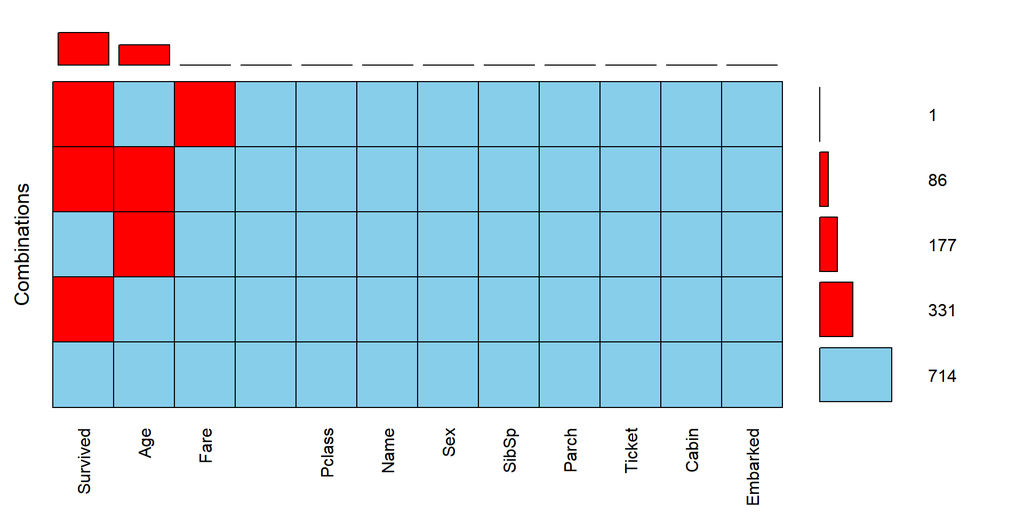

```
 Variables sorted by number of missings:
    Variable Count
    Survived   418
         Age   263
        Fare     1
 PassengerId     0
      Pclass     0
        Name     0
         Sex     0
       SibSp     0
       Parch     0
      Ticket     0
       Cabin     0
    Embarked     0
```

```r
VIM::aggr(tdata, prop = FALSE, combined = TRUE, numbers = TRUE,
          sortVars = TRUE, sortCombs = TRUE)
```

### 결측치 시각화2

```r
missing_values <- tdata %>%
  dplyr::summarise_all(funs(sum(is.na(.))/n()))
```

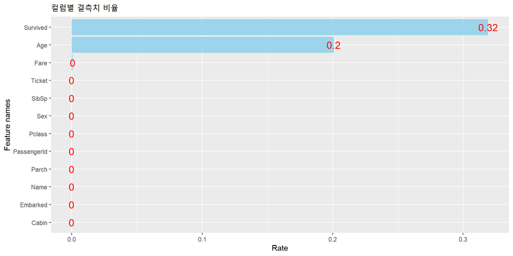

```r
missing_values <- tidyr::gather(missing_values,
                                key = 'feature', value = 'missing_pct')

missing_values %>%
  ggplot(aes(x = reorder(feature, missing_pct), y = missing_pct)) +
  geom_bar(stat = 'identity', fill = 'sky blue', alpha = 0.8) +
  geom_text(aes(x = reorder(feature, missing_pct), label = round(missing_pct,2)),
            vjust=0.5, color="red",size=5) +
  ggtitle('컬럼별 결측치 비율') +
  labs(x = 'Feature names', y = 'Rate')  +
  coord_flip()
```

생존여부 예측 418건 결측치 전체 데이터중 32% test data, 68%는 라벨이 존재하는 train data  
나이 결측치 263건, 요금 결측치 1건 입니다.

## 2-3 결측치 처리

### Age

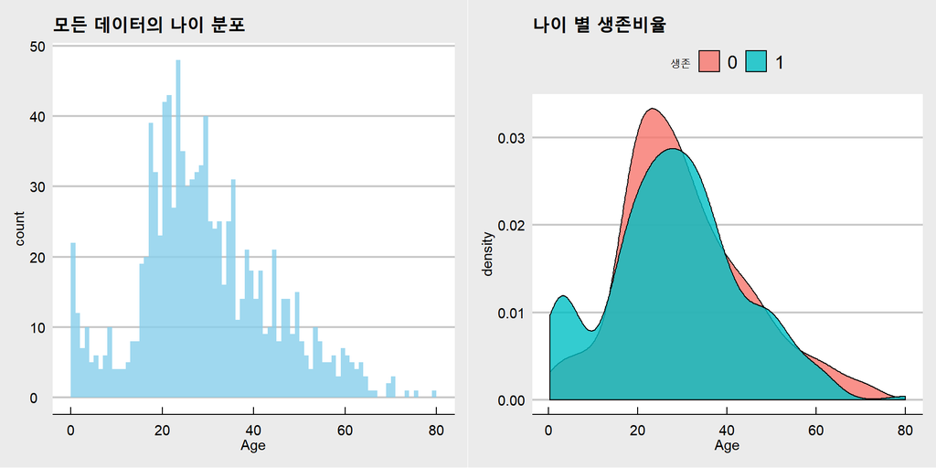

나이가 어린 경우 생존한 사람수가 많은 것을 확인 할 수 있다. 나이 결측치 처리는 중요합니다.  
나이를 추측할 수 있는 자료 : 이름에 붙어있는 호칭의 중앙값으로 처리합니다.

```r
#이름에서 호칭을 출력하는 과정
#head(tdata$Name)
n1<-data.frame(separate(data=tdata, col=Name,
                        sep="., ", into=c("name_1","name_2")))
#n1$name_2
n2<-separate(data=n1, col=name_2,
             sep="[:punct:]", into=c("name_2","name_3"))
#n2$name_2
#table(n1$name_1) # 성
table(n2$name_2) # 18개의 호칭
```

```
        Capt          Col          Don         Dona           Dr
           1            4            1            1            8
    Jonkheer         Lady        Major       Master         Miss
           1            1            2           61          260
        Mlle          Mme           Mr          Mrs           Ms
           2            1          757          197            2
         Rev          Sir the Countess
           8            1            1
```

```r
# 호칭은 성별과 나이가 어느정도 들어난다.
# 호칭을 그룹화 하고 그룹별 평균으로 나이 결측치를 대체한다.
tdata$nametitle<-n2$name_2
tdata$lastname<-n1$name_1

#str(tdata)
#head(tdata)
aggregate(Age~nametitle, tdata, median)
```

```
      nametitle  Age
1          Capt 70.0
2           Col 54.5
3           Don 40.0
4          Dona 39.0
5            Dr 49.0
6      Jonkheer 38.0
7          Lady 48.0
8         Major 48.5
9        Master  4.0
10         Miss 22.0
11         Mlle 24.0
12          Mme 24.0
13           Mr 29.0
14          Mrs 35.5
15           Ms 28.0
16          Rev 41.5
17          Sir 49.0
18 the Countess 33.0
```

```r
# 호칭의 중앙값을 이용하여 데이터처리
Na_age<-as.data.frame(aggregate(Age~nametitle, tdata, median))
summary(tdata$Age)
```

```
   Min. 1st Qu.  Median    Mean 3rd Qu.    Max.    NA's
   0.17   21.00   28.00   29.88   39.00   80.00     263
```

```r
tdata$age2<-tdata$Age
for(i in 1:nrow(tdata)){

  if(is.na(tdata[i,"age2"])){

    tdata[i,"age2"]<-Na_age[Na_age$nametitle==tdata[i,"nametitle"], "Age"]

  }
}
summary(tdata$age2)
```

```
   Min. 1st Qu.  Median    Mean 3rd Qu.    Max.
   0.17   22.00   29.00   29.43   35.50   80.00
```

```r
colSums(is.na(tdata))
```

```
PassengerId    Survived      Pclass        Name         Sex         Age
          0         418           0           0           0         263
      SibSp       Parch      Ticket        Fare       Cabin    Embarked
          0           0           0           1           0           0
  nametitle    lastname        age2
          0           0           0
```

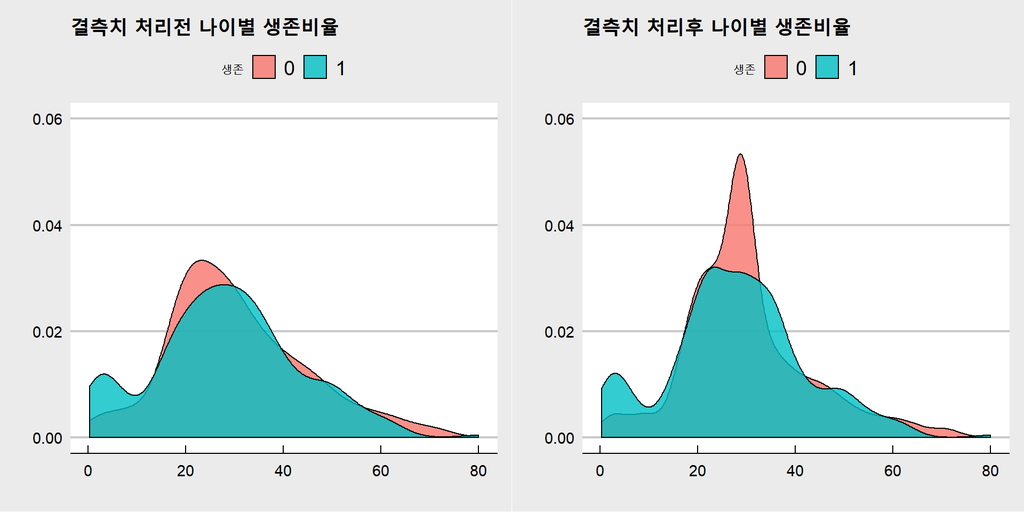

나이는 이름에 들어있는 호칭을 이용하여 결측치를 처리합니다.  
결측치를 처리한 후 비교 결과 20~40 사망비율이 증가한 것을 확인할 수 있습니다.

### Fare

```r
# 요금 결측치 처리
tdata[is.na(tdata$Fare),]
```

```
     PassengerId Survived Pclass               Name  Sex  Age SibSp Parch
1044        1044     <NA>      3 Storey, Mr. Thomas male 60.5     0     0
     Ticket Fare Cabin Embarked nametitle lastname age2
1044   3701   NA              S        Mr    Store 60.5
```

```r
tdata[tdata$Ticket==3701,] # 동일 티켓 1명
```

```
     PassengerId Survived Pclass               Name  Sex  Age SibSp Parch
1044        1044     <NA>      3 Storey, Mr. Thomas male 60.5     0     0
     Ticket Fare Cabin Embarked nametitle lastname age2
1044   3701   NA              S        Mr    Store 60.5
```

```r
aggregate(Fare~Pclass+Embarked, tdata, median)
```

```
   Pclass Embarked    Fare
1       1          80.0000
2       1        C 76.7292
3       2        C 15.3146
4       3        C  7.8958
5       1        Q 90.0000
6       2        Q 12.3500
7       3        Q  7.7500
8       1        S 52.0000
9       2        S 15.3750
10      3        S  8.0500
```

```r
# 좌석등급이 3등급이고 출발항구가 S인 중앙값으로 처리
tdata$Fare<-ifelse(tdata$PassengerId==1044, 8, tdata$Fare)

summary(tdata$Fare)
```

```
   Min. 1st Qu.  Median    Mean 3rd Qu.    Max.
  0.000   7.896  14.454  33.276  31.275 512.329
```

```r
# 요금이 0인 사람이 존재
nrow(tdata[tdata$Fare==0,])
```

```
[1] 17
```

```r
# 모두 남성이고 동행한 사람이 없음, S항구에서 출발
# summary(tdata[tdata$Fare==0,'Ticket'])
# LINE 이라는 티켓과 239853 티켓을 가진 사람들이 각각 4명 3명 티켓번호 일관성 없음
# 직원으로 추측해 볼 수 있다. 0원인 사람들 처리는 하지 않는다.

str(tdata)
```

```
'data.frame':   1309 obs. of  15 variables:
 $ PassengerId: int  1 2 3 4 5 6 7 8 9 10 ...
 $ Survived   : Factor w/ 2 levels "0","1": 1 2 2 2 1 1 1 1 2 2 ...
 $ Pclass     : Ord.factor w/ 3 levels "1"<"2"<"3": 3 1 3 1 3 3 1 3 3 2 ...
 $ Name       : chr  "Braund, Mr. Owen Harris" "Cumings, Mrs. John Bradley (Florence Briggs Thayer)" "Heikkinen, Miss. Laina" "Futrelle, Mrs. Jacques Heath (Lily May Peel)" ...
 $ Sex        : Factor w/ 2 levels "female","male": 2 1 1 1 2 2 2 2 1 1 ...
 $ Age        : num  22 38 26 35 35 NA 54 2 27 14 ...
 $ SibSp      : int  1 1 0 1 0 0 0 3 0 1 ...
 $ Parch      : int  0 0 0 0 0 0 0 1 2 0 ...
 $ Ticket     : Factor w/ 929 levels "110152","110413",..: 721 817 915 66 650 374 110 542 478 175 ...
 $ Fare       : num  7.25 71.28 7.92 53.1 8.05 ...
 $ Cabin      : Factor w/ 187 levels "","A10","A11",..: 1 108 1 72 1 1 165 1 1 1 ...
 $ Embarked   : Factor w/ 4 levels "","C","Q","S": 4 2 4 4 4 3 4 4 4 2 ...
 $ nametitle  : chr  "Mr" "Mrs" "Miss" "Mrs" ...
 $ lastname   : chr  "Braun" "Cuming" "Heikkine" "Futrell" ...
 $ age2       : num  22 38 26 35 35 29 54 2 27 14 ...
```

요금 결측치는 좌석등급과 출발항구를 고려하여 그 중앙값으로 처리합니다.

### Embarked

```r
summary(tdata$Embarked)
```

```
      C   Q   S
  2 270 123 914
```

```r
table(tdata$Embarked)
```

```
      C   Q   S
  2 270 123 914
```

```r
tdata[tdata$Embarked=="",]
```

```
    PassengerId Survived Pclass                                      Name
62           62        1      1                       Icard, Miss. Amelie
830         830        1      1 Stone, Mrs. George Nelson (Martha Evelyn)
       Sex Age SibSp Parch Ticket Fare Cabin Embarked nametitle lastname
62  female  38     0     0 113572   80   B28               Miss     Icar
830 female  62     0     0 113572   80   B28                Mrs     Ston
    age2
62    38
830   62
```

```r
tdata[tdata$Ticket=="113572",]
```

```
    PassengerId Survived Pclass                                      Name
62           62        1      1                       Icard, Miss. Amelie
830         830        1      1 Stone, Mrs. George Nelson (Martha Evelyn)
       Sex Age SibSp Parch Ticket Fare Cabin Embarked nametitle lastname
62  female  38     0     0 113572   80   B28               Miss     Icar
830 female  62     0     0 113572   80   B28                Mrs     Ston
    age2
62    38
830   62
```

```r
tdata[tdata$Cabin=="B28",]
```

```
    PassengerId Survived Pclass                                      Name
62           62        1      1                       Icard, Miss. Amelie
830         830        1      1 Stone, Mrs. George Nelson (Martha Evelyn)
       Sex Age SibSp Parch Ticket Fare Cabin Embarked nametitle lastname
62  female  38     0     0 113572   80   B28               Miss     Icar
830 female  62     0     0 113572   80   B28                Mrs     Ston
    age2
62    38
830   62
```

```r
same_cabin<-tdata[grep("^B", tdata$Cabin),]
aggregate(Fare~Pclass+Embarked, same_cabin, median)
```

```
  Pclass Embarked    Fare
1      1          80.0000
2      1        C 91.0792
3      1        S 82.2667
```

```r
tdata[tdata$Ticket=="113572","Embarked"]<-"S"
tdata$Embarked<-factor(tdata$Embarked, levels=c('C','Q','S'))

str(tdata)
```

```
'data.frame':   1309 obs. of  15 variables:
 $ PassengerId: int  1 2 3 4 5 6 7 8 9 10 ...
 $ Survived   : Factor w/ 2 levels "0","1": 1 2 2 2 1 1 1 1 2 2 ...
 $ Pclass     : Ord.factor w/ 3 levels "1"<"2"<"3": 3 1 3 1 3 3 1 3 3 2 ...
 $ Name       : chr  "Braund, Mr. Owen Harris" "Cumings, Mrs. John Bradley (Florence Briggs Thayer)" "Heikkinen, Miss. Laina" "Futrelle, Mrs. Jacques Heath (Lily May Peel)" ...
 $ Sex        : Factor w/ 2 levels "female","male": 2 1 1 1 2 2 2 2 1 1 ...
 $ Age        : num  22 38 26 35 35 NA 54 2 27 14 ...
 $ SibSp      : int  1 1 0 1 0 0 0 3 0 1 ...
 $ Parch      : int  0 0 0 0 0 0 0 1 2 0 ...
 $ Ticket     : Factor w/ 929 levels "110152","110413",..: 721 817 915 66 650 374 110 542 478 175 ...
 $ Fare       : num  7.25 71.28 7.92 53.1 8.05 ...
 $ Cabin      : Factor w/ 187 levels "","A10","A11",..: 1 108 1 72 1 1 165 1 1 1 ...
 $ Embarked   : Factor w/ 3 levels "C","Q","S": 3 1 3 3 3 2 3 3 3 1 ...
 $ nametitle  : chr  "Mr" "Mrs" "Miss" "Mrs" ...
 $ lastname   : chr  "Braun" "Cuming" "Heikkine" "Futrell" ...
 $ age2       : num  22 38 26 35 35 29 54 2 27 14 ...
```

Cabin이 B로 시작하는 데이터중 등급별 항구별 가격의 중앙값비교후 ’S’로 처리합니다.

### Cabin

```r
# cabin 결측치 처리
# summary(tdata$Cabin)
nrow(tdata[tdata$Cabin=="",]) # 1014 건 결측치
```

```
[1] 1014
```

결측치가 많은 Cabin은 등급(Pclass)와 가격(Fare)이 대체할수 있다고 판단했습니다. 이 컬럼은 분석에서 제외합니다.

## 2-4. 데이터 준비

```r
str(tdata)
```

```
'data.frame':   1309 obs. of  15 variables:
 $ PassengerId: int  1 2 3 4 5 6 7 8 9 10 ...
 $ Survived   : Factor w/ 2 levels "0","1": 1 2 2 2 1 1 1 1 2 2 ...
 $ Pclass     : Ord.factor w/ 3 levels "1"<"2"<"3": 3 1 3 1 3 3 1 3 3 2 ...
 $ Name       : chr  "Braund, Mr. Owen Harris" "Cumings, Mrs. John Bradley (Florence Briggs Thayer)" "Heikkinen, Miss. Laina" "Futrelle, Mrs. Jacques Heath (Lily May Peel)" ...
 $ Sex        : Factor w/ 2 levels "female","male": 2 1 1 1 2 2 2 2 1 1 ...
 $ Age        : num  22 38 26 35 35 NA 54 2 27 14 ...
 $ SibSp      : int  1 1 0 1 0 0 0 3 0 1 ...
 $ Parch      : int  0 0 0 0 0 0 0 1 2 0 ...
 $ Ticket     : Factor w/ 929 levels "110152","110413",..: 721 817 915 66 650 374 110 542 478 175 ...
 $ Fare       : num  7.25 71.28 7.92 53.1 8.05 ...
 $ Cabin      : Factor w/ 187 levels "","A10","A11",..: 1 108 1 72 1 1 165 1 1 1 ...
 $ Embarked   : Factor w/ 3 levels "C","Q","S": 3 1 3 3 3 2 3 3 3 1 ...
 $ nametitle  : chr  "Mr" "Mrs" "Miss" "Mrs" ...
 $ lastname   : chr  "Braun" "Cuming" "Heikkine" "Futrell" ...
 $ age2       : num  22 38 26 35 35 29 54 2 27 14 ...
```

```r
# 연속형 변수
summary(tdata[,c("age2","SibSp","Parch","Fare")])
```

```
      age2           SibSp            Parch            Fare
 Min.   : 0.17   Min.   :0.0000   Min.   :0.000   Min.   :  0.000
 1st Qu.:22.00   1st Qu.:0.0000   1st Qu.:0.000   1st Qu.:  7.896
 Median :29.00   Median :0.0000   Median :0.000   Median : 14.454
 Mean   :29.43   Mean   :0.4989   Mean   :0.385   Mean   : 33.276
 3rd Qu.:35.50   3rd Qu.:1.0000   3rd Qu.:0.000   3rd Qu.: 31.275
 Max.   :80.00   Max.   :8.0000   Max.   :9.000   Max.   :512.329
```

```r
# 명목형 변수
summary(tdata[,c("Survived","Pclass","Sex","nametitle","Ticket","Embarked")])
```

```
 Survived   Pclass      Sex       nametitle              Ticket
 0   :549   1:323   female:466   Length:1309        CA. 2343:  11
 1   :342   2:277   male  :843   Class :character   1601    :   8
 NA's:418   3:709                Mode  :character   CA 2144 :   8
                                                    3101295 :   7
                                                    347077  :   7
                                                    347082  :   7
                                                    (Other) :1261
 Embarked
 C:270
 Q:123
 S:916
```

### Age

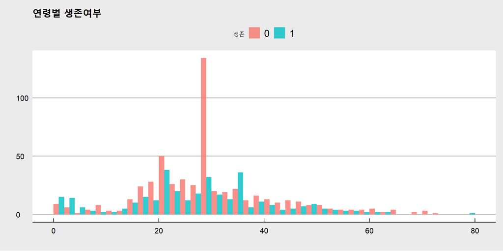

나이가 4세미만인 경우, 생존자가 사망자보다 더 많이 존재합니다. 대부분 구간에서는 생존자보다 사망자가 많이 존재합니다. 나이를 연속형으로 사용하여 모델을 생성하거나 구간을 나누어 모델을 생성할 수 있습니다. 모델을 생성후 고려해볼 필요가 있는 특징입니다.

### nametitle

```r
# 변수 정리 : nametitle factor형 변수
table(tdata$nametitle)
```

```
        Capt          Col          Don         Dona           Dr
           1            4            1            1            8
    Jonkheer         Lady        Major       Master         Miss
           1            1            2           61          260
        Mlle          Mme           Mr          Mrs           Ms
           2            1          757          197            2
         Rev          Sir the Countess
           8            1            1
```

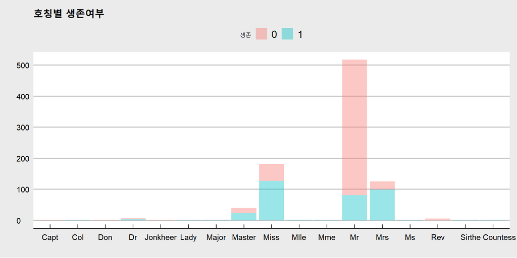

```r
# 호칭별 생존여부도 의미가 있다.
# 호칭이 나이와 성별을 갖는 컬럼. 서로 다른 호칭이 18개 존재

ggplot(tdata[!is.na(tdata$Survived),]) +
  geom_bar(aes(x = as.factor(nametitle), fill = as.factor(Survived)),alpha = 0.4) +
  xlab("") + ylab("") + labs(fill="생존") +
  theme_economist_white() + ggtitle("호칭별 생존여부")
```

```r
# 호칭 정리
tdata$nametitle<-ifelse(tdata$nametitle %in% c("Mr","Jonkheer","Don"), "Mr",tdata$nametitle)
tdata$nametitle<-ifelse(tdata$nametitle %in% c("Mrs","Mme","Dona","Ms"), "Mrs",tdata$nametitle)
tdata$nametitle<-ifelse(tdata$nametitle %in% c("Miss","Mlle"), "Miss",tdata$nametitle)
tdata$nametitle<-ifelse(tdata$nametitle %in% c("Col", "Major","Capt","Dr","Rev"), "Millitary",tdata$nametitle)
tdata$nametitle<-ifelse(tdata$nametitle %in% c("Lady","the Countess","Sir"), "Honor",tdata$nametitle)


table(tdata$nametitle)
```

```
    Honor    Master Millitary      Miss        Mr       Mrs
        3        61        23       262       759       201
```

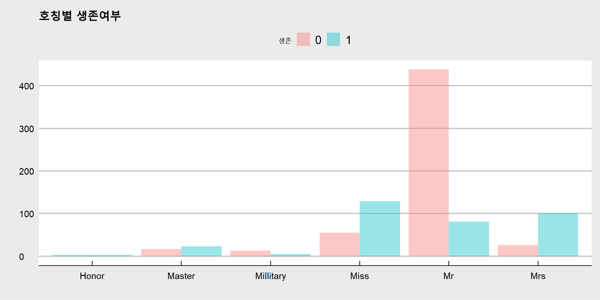

```r
ggplot(tdata[!is.na(tdata$Survived),]) +
  geom_bar(aes(x = as.factor(nametitle), fill = as.factor(Survived)),alpha = 0.4, position="dodge") +
  xlab("") + ylab("") + labs(fill = "생존") +
  theme_economist_white() + ggtitle("호칭별 생존여부")
```

```r
tdata$nametitle<-factor(tdata$nametitle)
```

호칭은 성별과 나이를 포함하고 있는 데이터가 됩니다. 여성이 남성에 비해 많이 생존했고, 남성을 나타내는 호칭충 Master는 Mr와 비교하면 생존한 사람이 더 많습니다.

### Pclass/Sex

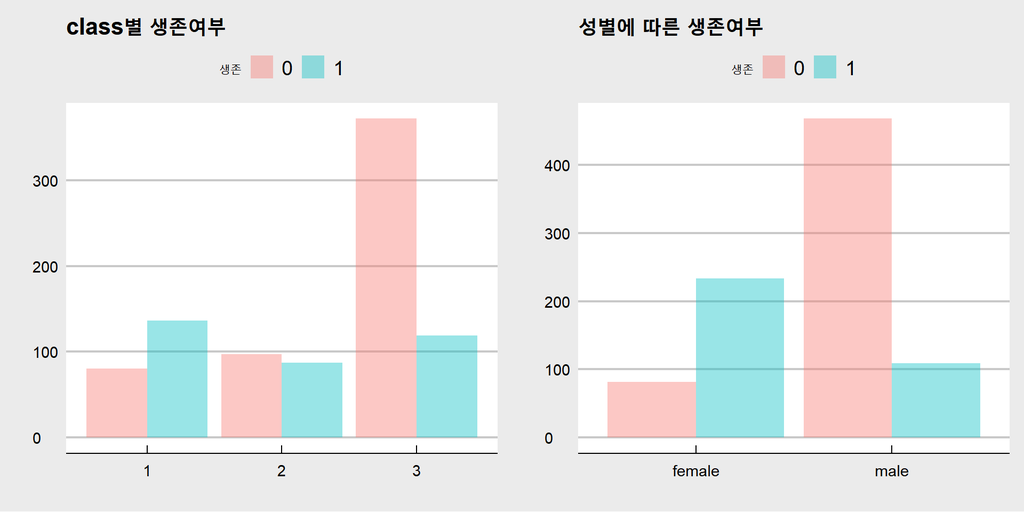

Pclass와 성별 모두 생존에 영향을 주는 변수라 할 수 있습니다.

### family(Parch, Sibsp)

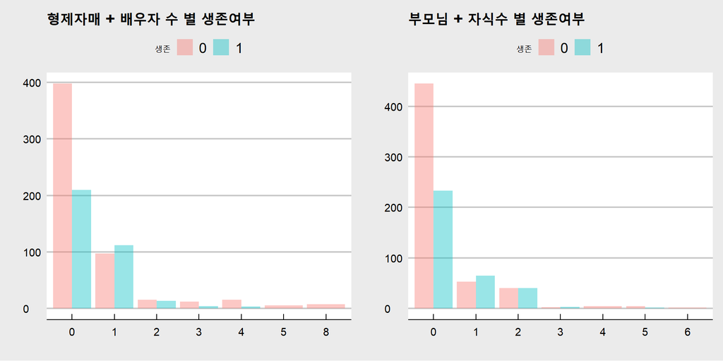

혼자 탑승한 사람의 사망자수가 많은것을 확인가능합니다. 파생변수를 만들 수 있습니다.

### Embarked

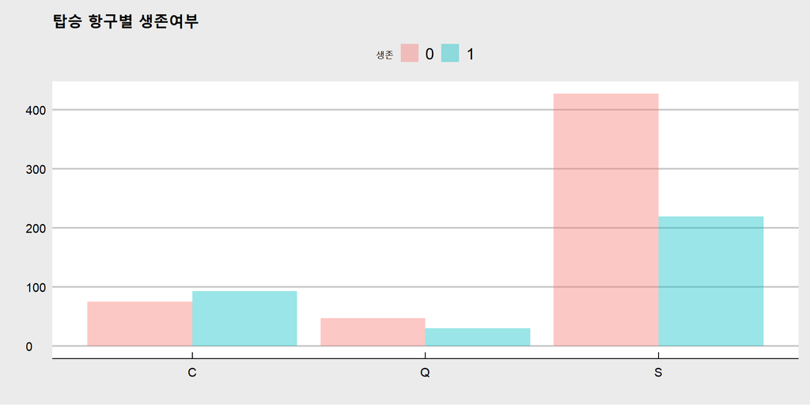

```r
ggplot(tdata[!is.na(tdata$Survived),]) +
  geom_bar(aes(x = as.factor(Embarked), fill = as.factor(Survived)),alpha = 0.4 , position="dodge") +
  xlab("") + ylab("") + labs(fill = "생존") +
  theme_economist_white() + ggtitle("탑승 항구별 생존여부")
```

```r
CrossTable(tdata$Embarked, tdata$Pclass, expected=FALSE, prop.r=F, prop.c=F,
           prop.t=F, prop.chisq=F, chisq = F)
```

```
   Cell Contents
|-------------------------|
|                       N |
|-------------------------|


Total Observations in Table:  1309


               | tdata$Pclass
tdata$Embarked |         1 |         2 |         3 | Row Total |
---------------|-----------|-----------|-----------|-----------|
             C |       141 |        28 |       101 |       270 |
---------------|-----------|-----------|-----------|-----------|
             Q |         3 |         7 |       113 |       123 |
---------------|-----------|-----------|-----------|-----------|
             S |       179 |       242 |       495 |       916 |
---------------|-----------|-----------|-----------|-----------|
  Column Total |       323 |       277 |       709 |      1309 |
---------------|-----------|-----------|-----------|-----------|
```

## 2-5. 변수조절, 파생변수 생성

### Family

부모님의 생존여부와 자녀의 생존 여부가 관련이 있을 것이라 생각했습니다.

```r
adata <- tdata[,-c(4,11)]
str(adata)
```

```
'data.frame':   1309 obs. of  13 variables:
 $ PassengerId: int  1 2 3 4 5 6 7 8 9 10 ...
 $ Survived   : Factor w/ 2 levels "0","1": 1 2 2 2 1 1 1 1 2 2 ...
 $ Pclass     : Ord.factor w/ 3 levels "1"<"2"<"3": 3 1 3 1 3 3 1 3 3 2 ...
 $ Sex        : Factor w/ 2 levels "female","male": 2 1 1 1 2 2 2 2 1 1 ...
 $ Age        : num  22 38 26 35 35 NA 54 2 27 14 ...
 $ SibSp      : int  1 1 0 1 0 0 0 3 0 1 ...
 $ Parch      : int  0 0 0 0 0 0 0 1 2 0 ...
 $ Ticket     : Factor w/ 929 levels "110152","110413",..: 721 817 915 66 650 374 110 542 478 175 ...
 $ Fare       : num  7.25 71.28 7.92 53.1 8.05 ...
 $ Embarked   : Factor w/ 3 levels "C","Q","S": 3 1 3 3 3 2 3 3 3 1 ...
 $ nametitle  : Factor w/ 6 levels "Honor","Master",..: 5 6 4 6 5 5 5 2 6 6 ...
 $ lastname   : chr  "Braun" "Cuming" "Heikkine" "Futrell" ...
 $ age2       : num  22 38 26 35 35 29 54 2 27 14 ...
```

```r
test1<-na.omit(adata[adata$Parch>1 & adata$age2>=18 & adata$Survived==1, 'lastname'])

table(adata[adata$lastname %in% test1 & adata$age2<18 & adata$Parch > 1,'Survived'], useNA = "ifany")
```

```
   0    1 <NA>
   1    6    5
```

```r
test2<-na.omit(adata[adata$Parch>1 & adata$age2>=18 & adata$Survived==0, 'lastname'])

table(adata[adata$lastname %in% test2 & adata$age2<18 & adata$Parch > 1,'Survived'], useNA = "ifany")
```

```
   0    1 <NA>
  18    5    6
```

보호자가 생존한 경우 그 자식이 생존한 경우가 많고, 반대의 경우 자식이 사망한 경우가 더 많았습니다.

```r
trainlastname<-unique(adata[!is.na(adata$Survived) & adata$Parch > 0, 'lastname'])
testlastname<-unique(adata[is.na(adata$Survived) & adata$Parch > 0, 'lastname'])

library(dplyr)
setdiff(testlastname, trainlastname)
```

```
[1] "Davidso" "Earnsha" "Peacoc"  "Dougla"  "Phillip" "Hiltune" "Gibso"
```

test data 에만 존재하는 성이 7가지로 파생변수 만들기는 적절치 않습니다. 따라서 가족의 동행여부(가족의 크기)에 따른 생존 여부를 확인했습니다.

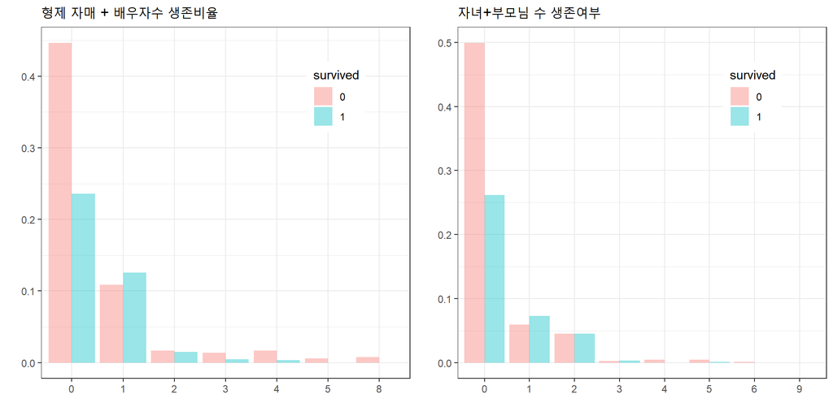

동행한 가족이 0명인 경우 사망한 사람 비율이 매우 높습니다.

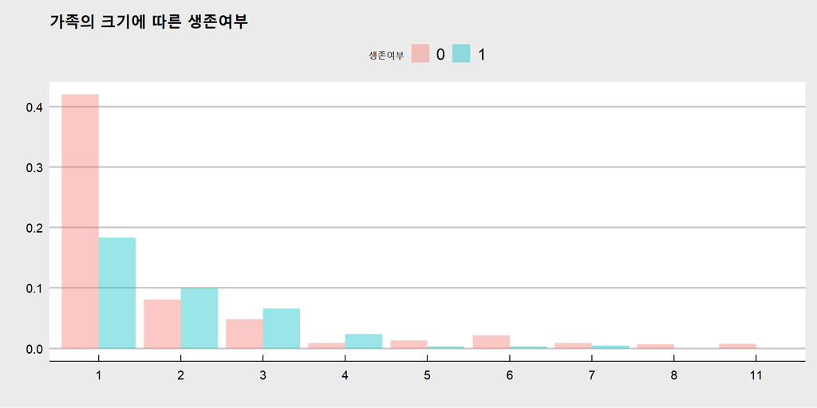

Sibsp, Parch 두 컬럼을 이용한 가족크기 파생변수 추가합니다. family size : Sibsp + Parch + 1 에 대한 생존여부 분포를 보고 3개의 그룹으로 나눴습니다. N : 1명 (혼자)  
S : 2명, 3명, 4명 -> 생존자가 더 많은 그룹  
L : 5명 이상

```r
adata <- adata %>%
  mutate(familysize = .$SibSp + .$Parch + 1,
         familysize = dplyr::case_when(familysize == 1 ~ "N",
                                       familysize >= 2 & familysize < 5 ~ "S",
                                       familysize >= 5 ~ "L"),
         familysize = factor(familysize, levels = c("N", "S", "L")))

table(adata$familysize)
```

```
  N   S   L
790 437  82
```

### Ticket

```r
# 고유번호를 갖는 ticket은 929가지로 너무 다양한 데이터이다.
length(unique(adata$Ticket))
```

```
[1] 929
```

```r
ticket_bin<-as.data.frame(table(adata$Ticket))
table(ticket_bin$Freq) # 고유한 티켓인 경우가 가장 많고 같은 티켓번호가 최대 11건까지 있다.
```

```
  1   2   3   4   5   6   7   8  11
713 132  49  16   7   4   5   2   1
```

```r
head(ticket_bin[order(-ticket_bin$Freq),])
```

```
        Var1 Freq
779 CA. 2343   11
105     1601    8
776  CA 2144    8
336  3101295    7
455   347077    7
460   347082    7
```

```r
adata[adata$Ticket == "CA. 2343",]
```

```
     PassengerId Survived Pclass    Sex  Age SibSp Parch   Ticket  Fare
160          160        0      3   male   NA     8     2 CA. 2343 69.55
181          181        0      3 female   NA     8     2 CA. 2343 69.55
202          202        0      3   male   NA     8     2 CA. 2343 69.55
325          325        0      3   male   NA     8     2 CA. 2343 69.55
793          793        0      3 female   NA     8     2 CA. 2343 69.55
847          847        0      3   male   NA     8     2 CA. 2343 69.55
864          864        0      3 female   NA     8     2 CA. 2343 69.55
1080        1080     <NA>      3 female   NA     8     2 CA. 2343 69.55
1234        1234     <NA>      3   male   NA     1     9 CA. 2343 69.55
1252        1252     <NA>      3   male 14.5     8     2 CA. 2343 69.55
1257        1257     <NA>      3 female   NA     1     9 CA. 2343 69.55
     Embarked nametitle lastname age2 familysize
160         S    Master      Sag  4.0          L
181         S      Miss      Sag 22.0          L
202         S        Mr      Sag 29.0          L
325         S        Mr      Sag 29.0          L
793         S      Miss      Sag 22.0          L
847         S        Mr      Sag 29.0          L
864         S      Miss      Sag 22.0          L
1080        S      Miss      Sag 22.0          L
1234        S        Mr      Sag 29.0          L
1252        S    Master      Sag 14.5          L
1257        S       Mrs      Sag 35.5          L
```

```r
# 한 티켓이 같은 가족
adata[adata$Ticket == "1601",]
```

```
    PassengerId Survived Pclass  Sex Age SibSp Parch Ticket    Fare
75           75        1      3 male  32     0     0   1601 56.4958
170         170        0      3 male  28     0     0   1601 56.4958
510         510        1      3 male  26     0     0   1601 56.4958
644         644        1      3 male  NA     0     0   1601 56.4958
693         693        1      3 male  NA     0     0   1601 56.4958
827         827        0      3 male  NA     0     0   1601 56.4958
839         839        1      3 male  32     0     0   1601 56.4958
931         931     <NA>      3 male  NA     0     0   1601 56.4958
    Embarked nametitle lastname age2 familysize
75         S        Mr      Bin   32          N
170        S        Mr      Lin   28          N
510        S        Mr      Lan   26          N
644        S        Mr       Fo   29          N
693        S        Mr       La   29          N
827        S        Mr       La   29          N
839        S        Mr      Chi   32          N
931        S        Mr       He   29          N
```

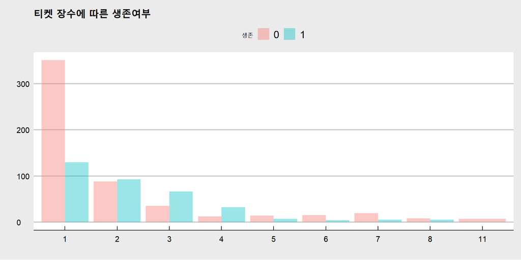

```r
# 가족이 아니지만 한 티켓인 경우도 존재한다.

# 티켓사이즈 파생변수 만들기
adata$ticket_num<-0
for(i in 1:nrow(adata)){
  row_ticket <- adata[i,'Ticket']
  adata[i, 'ticket_num'] <- ticket_bin[ticket_bin$Var1 == row_ticket, 'Freq' ]
}

ggplot(adata[!is.na(adata$Survived),]) +
  geom_bar(aes(x = as.factor(ticket_num), fill = as.factor(Survived)),alpha = 0.4, position="dodge") +
  xlab("") + ylab("") + labs(fill = "생존") +
  theme_economist_white() + ggtitle("티켓 장수에 따른 생존여부")
```

```r
adata <- adata %>%
  mutate( ticket_num = dplyr::case_when(ticket_num == 1 ~ "N",
                                       ticket_num >= 2 & ticket_num < 5 ~ "S",
                                       ticket_num >= 5 ~ "L"),
         ticket_num = factor(ticket_num, levels = c("N", "S", "L")))

str(adata)
```

```
'data.frame':   1309 obs. of  15 variables:
 $ PassengerId: int  1 2 3 4 5 6 7 8 9 10 ...
 $ Survived   : Factor w/ 2 levels "0","1": 1 2 2 2 1 1 1 1 2 2 ...
 $ Pclass     : Ord.factor w/ 3 levels "1"<"2"<"3": 3 1 3 1 3 3 1 3 3 2 ...
 $ Sex        : Factor w/ 2 levels "female","male": 2 1 1 1 2 2 2 2 1 1 ...
 $ Age        : num  22 38 26 35 35 NA 54 2 27 14 ...
 $ SibSp      : int  1 1 0 1 0 0 0 3 0 1 ...
 $ Parch      : int  0 0 0 0 0 0 0 1 2 0 ...
 $ Ticket     : Factor w/ 929 levels "110152","110413",..: 721 817 915 66 650 374 110 542 478 175 ...
 $ Fare       : num  7.25 71.28 7.92 53.1 8.05 ...
 $ Embarked   : Factor w/ 3 levels "C","Q","S": 3 1 3 3 3 2 3 3 3 1 ...
 $ nametitle  : Factor w/ 6 levels "Honor","Master",..: 5 6 4 6 5 5 5 2 6 6 ...
 $ lastname   : chr  "Braun" "Cuming" "Heikkine" "Futrell" ...
 $ age2       : num  22 38 26 35 35 29 54 2 27 14 ...
 $ familysize : Factor w/ 3 levels "N","S","L": 2 2 1 2 1 1 1 3 2 2 ...
 $ ticket_num : Factor w/ 3 levels "N","S","L": 1 2 1 2 1 1 2 3 2 2 ...
```

```r
nrow(adata[adata$familysize==adata$ticket_num,]) # 1110 건 둘이 비슷한 파생변수
```

```
[1] 1110
```

ticket_num과 family_size가 같은경우가 1110건으로 둘이 매우 비숫한 파생변수입니다.  
모델을 생성하는데 있어 변수 선택시 고려해야할 부분입니다.